# Numerical Methods to Optimal Control Part-1

Sarder Rafee Musabbir \ UC Davis Intelligent Mobility Laboratory (IMobiL) \ Advisor: Prof. Michael Zhang

# Presentation Overview

1. How to form an optimal control problem?
2. How to solve a particular type of optimal control problem?
3. What are the exact and approximate methods to solve the optimal control problem numerically?
4. Which methods are in common in practice and easy to implement?
5. How to transform the optimal control problem to solve in a particular method?
6. How all this is relevant for a transportation related problem?

# Prerequisite to Solve a Optimal Control Problem

1. Numerical Methods of optimization
   - Bisection Method
   - Newton Method
   - Secant Method
2. Convex Optimization
3. Non-Linear Optimization
4. Mixed Integer Programming

# Some Core Concept

1. Discrete control
2. Continuous control

# Discrete Control: Bellman Equations

The **Optimal Control** problem can be formalized using **Dynamic Programming** concept as follows: find an action sequence $(u_0, u_1,...u_{n-1})$ and corresponding state sequence $(x_0, x_1,...x_{n-1})$ minimizing the total cost:

$$J(x,u) = \sum_{k=0}^{n-1} \text{cost}(x_k,u_k)$$

where, $x_{k+1} = \text{next} (x_k, u_k)$ and $u_k \in \mathcal{U}(x_k)$. The initial state $x_0 = x^{\text{init}}$ and destination state $x_n = x^{\text{dest}}$ are given. We can visualize this setting with a directed graph where the states are nodes and the actions are arrows connecting the nodes. If $\text{cost} (x, u) = 1$ for all $(x, u)$ the problem reduces to finding the shortest path from $x^{\text{init}}$ to $x^{\text{dest}}$ in the graph.

## Dynamic Programming

Dynamic Programming (DP) relies on the following obvious fact: if a given state-action sequence is optimal, and we were to remove the first state and action, the remaining sequence is also optimal (with the second state of the original sequence now acting as initial state). This is the Bellman optimality principle.

Note the close resemblance to the Markov property of stochastic processes (a process is Markov if its future is conditionally independent of the past given the present state).

**The optimality principle can be reworded in similar language: the choice of optimal actions in the future is independent of the past actions which led to the present state. Thus optimal state-action sequences can be constructed by starting at the final state and extending backwards. Key to this procedure is the optimal value function (or optimal cost-to-go function)**

$$v(x) = \text{minimal total cost for completing the task starting from state} \quad x$$

This value function captures the long-term cost for starting from a given state, and makes it possible to find optimal actions through the following algorithm:

- **Consider every action available at the current state, add its immediate cost to the optimal value of the resulting next state, and choose an action for which the sum is minimal.**
- **The above algorithm is "greedy" in the sense that actions are chosen based on local information, without explicit consideration of all future scenarios. And yet the resulting actions are optimal. This is possible because the optimal value function contains all information about future scenarios that is relevant to the present choice of action.** Thus the optimal value function is an extremely useful quantity, and indeed its calculation is at the heart of many methods for optimal control.

Value iteration uses only $v(x)$. We start with a guess $v^{0}$ of the optimal value function, and construct a sequence of improved guesses:

$$v^{i+1}(x) = \min_{u\in \mathcal{U}(x)} \Big\{ \text{cost}(x,u) + v^i (next (x,u)) \Big\}$$

This process is guaranteed to converge to the optimal value function $v$ in a finite number of iterations.

# Continuous Control: Hamilton-Jacobi-Bellman eqn.

We now turn to optimal control problems where the state $\mathbf{x} \in \mathbb{R}^{nx}$ and control $\mathbf{u} \in \mathcal{U}(x) \in \mathbb{R}^{n_u}$ are real-valued vectors. To simplify notation we will use the shortcut $\min_u$ instead of $\min_{u\in \mathcal{U}}$, although the latter is implied unless noted otherwise. consider the stochastic differential equation,

$$\text{stochastic dynamics:} \quad d\mathbf{x} = \mathbf{f}(\mathbf{x}, \mathbf{u}) dt + F (\mathbf{x}, \mathbf{u}) d\mathbf{w}$$

where, $d\mathbf{w}$ is $n_w-$dimensional Brownian motion. This is sometimes called a controlled Ito diffusion, with $f(\mathbf{x},\mathbf{u})$ being the drift and $F(\mathbf{x}, \mathbf{u})$ the diffusion coefficient.

$\text{Meaning of the Dynamics:} \quad \mathbf{x}(t) = \mathbf{x}(0) + \int_{0}^{t} \mathbf{f}(\mathbf{x}(s), \mathbf{u}(s)) ds + \int_{0}^{t} F(\mathbf{x}(s), \mathbf{u}(s))d\mathbf{w}(s)$

$$\text{Cost in Continuous time:} \quad J(\mathbf{x}(\cdot), \mathbf{u}(\cdot)) = h(\mathbf{x}(t_f)) + \int_{0}^{t_f} \ell (\mathbf{x}(t), \mathbf{u}(t), t) dt$$

Objective is to find the control law $\mathbf{u} = \pi (\mathbf{x},t)$ that minimizes the expected total cost $\mathbf{J}$ for starting at a given $(\mathbf{x},t)$

$$\text{Euler Discretization:} \quad \mathbf{x}_{k+1} = \mathbf{x}_k + \Delta f(\mathbf{x}_k, \mathbf{u}_k) + \sqrt\Delta F (\mathbf{x}_k, \mathbf{u}_k)\varepsilon_k$$

where $\Delta$ is the time step, $\varepsilon_k \sim \mathcal{N}(0, I^{n_w})$ and $\mathbf{x}_k = \mathbf{x}(k \Delta)$. The $\sqrt\Delta$ term appears because the variance of Brownian motion grows linearly with time, and thus the standard deviation of the discrete-time noise should scale as $\sqrt\Delta$.

$$\text{Cost in Discrete time:} \quad J(\mathbf{x.}, \mathbf{u.}) = h(\mathbf{x_n}) + \Delta \sum_{k=0}^{n-1} \ell (\mathbf{x_k}, \mathbf{u_k}, k\Delta)$$$$\text{number of time steps:} \quad n=t_f/\Delta$$

## Hamilton-Jacobi-Bellman eqn.

### Stochastic Dynamics

$$v(\mathbf{x}, k) = \min_{\mathbf{u}} \Big\{ \Delta \ell(\mathbf{x}, \mathbf{u}, k\Delta) + E \big[ v (\mathbf{x} + \Delta f(\mathbf{x}, \mathbf{u}) + \xi, \ k+1) \big] \Big\}$$

Consider the second-order Taylor-series expansion of $v$, with the time index $k+1$ suppressed for clarity:

$$v(\mathbf{x} + \delta) = v(\mathbf{x}) + \delta^T v_{\mathbf{x}}(\mathbf{x}) + \frac{1}{2} \delta^T v_{\mathbf{x}\mathbf{x}} (\mathbf{x}) \delta + o(\delta^3)$$$$\delta = \Delta f(\mathbf{x}, \mathbf{u}) + \xi, \quad v_{\mathbf{x}}=\frac{\partial v}{\partial \mathbf{x}}, \quad v_{\mathbf{x}\mathbf{x}}=\frac{\partial^2 v}{\partial \mathbf{x} \partial \mathbf{x}}$$

The trace term appears because,

$$E\big[ \xi^T v_{\mathbf{x}\mathbf{x}} \xi\big] = E \big[tr(\xi \xi^T v_{\mathbf{x}\mathbf{x}}) \big] = tr\big( \text{Cov} [\xi] v_{\mathbf{x}\mathbf{x}} \big) = tr(\Delta S v_{\mathbf{x}\mathbf{x}})$$

$$v_t(\mathbf{x},t) = \min_{\mathbf{u} \in \mathcal{U}(x)} \Big\{ \ell (\mathbf{x}, \mathbf{u}, t) + f(\mathbf{x}, \mathbf{u})^T v_{\mathbf{x}} (\mathbf{x}, t) + \frac{1}{2} tr(S(\mathbf{x}, \mathbf{u}) v_{\mathbf{x}\mathbf{x}}(x,t)) \Big\}$$

# Optimal Control Example: Cannon

Suppose that you have a cannon, and you would like to hit a known target. To make things interesting, let's assume that there is air friction and that you would like to minimize the amount of powder used for the shot.

This situation can be modeled as a boundary-value-problem, since you know where the trajectory (path of the cannon ball) should start and end. The goal is to find the trajectory, including the initial velocity of the cannon ball. We will assume that:

(1). the cannon ball is a point mass, \ (2). air friction is modeled using quadratic drag, and \ (3). amount of powder is proportional to initial speed squared.

[figure not shown]

## Solution: Cannon Single Shooting

Single shooting works by approximating the trajectory using a single simulation. In other words, fire the cannon, check where the ball landed, adjust the initial speed, repeat. In math terms, the error between the target and where the cannon ball landed is called a defect. The optimization algorithm will try to find the initial speed such that this defect driven to zero. It turns out that single shooting is an effective method for simple problems (like this one), but it will fail on problems that are more difficult.

[figure not shown]

## Solution: Cannon Multiple Shooting

Multiple shooting is very similar to single shooting, but it turns out to be much more robust on difficult problems. It works by breaking the original problem into many small problems, and then solving them in parallel. At the end, each segment is constrained to connect to the previous one.

[figure not shown]

## Solution: Cannon Direct Collocation

Direct collocation is a bit more difficult to visualize, since there is no simulation step. Instead, the trajectory is approximated using a piecewise polynomial. Physics are satisfied by requiring that the dynamics (derivative of the state) match the derivative of the polynomial at each collocation point - the points that implicitly define the polynomial. In effect, shooting methods satisfy dynamics using explicit integration, while collocation methods use implicit integration.

There are a wide variety of collocation schemes. Orthogonal collocation schemes, developed for computing satellite trajectories, use a small number of high-order polynomials. They are extremely accurate for problems well behaved solutions. The other extreme is direct collocation, which uses a large number of low-order polynomials to represent the solution. It tends to be slightly less accurate, but can be more robust. Some sophisticated methods (GPOPS) use an adaptive meshing routine to iterative change the number of segments and order of the polynomials.

[figure not shown]

## An important topic to add

a. How to discretize and linearize a nonlinear continuous system encountered in a vehicle related problem?

- Discretize the continuous system
- Linearize the nonlinear system

**More on discretization and linearization on the Linear Quadratic Gaussian Lecture**

# Slot Car Racing Problem

*Racing a toy slot car*

The task is to finish $1$ lap as fast as possible, starting from standstill. Go too fast, and the car will fly out of its slot. There is just one way to control the system: pick the amount of acceleration $u(t)$ at any give time.

First, we encode the knowledge we have about the system dynamics in a differential equation (ODE):

$$\frac{d\big[p(t) \ v(t) \big]}{dt} = \big[v(t)\ u(t) - v(t) \big]$$

where $p$ is the position and $v(t)$ is speed.

[figure not shown]

## A continuous-time optimal control problem

$$\begin{align} &\text{State:} \quad x(t) = [p(t), v(t)] \\ &\text{State Dynamics:} \quad \dot{x}(t) = f(x(t), u(t)) \\ &\text{Objective function:} \quad \min_{x(\cdot),u(\cdot)} T \\ &\text{Dynamic Constraints:} \quad \dot{x}(t) = f(x(t), u(t)) \quad t\in [0,T] \\ &\text{Boundary condition 1:} \quad p(0) = 0 \quad \text{start at position 0} \\ &\text{Boundary condition 2:} \quad v(0) = 0 \quad \text{start with zero speed} \\ &\text{Boundary condition 3:} \quad p(T) = 1 \quad \text{the finish line is at position 1} \\ &\text{Path constraint 1:} \quad 0 \leq u(t) \leq 1 \quad \text{throttle is limited} \\ &\text{Path constraint 2:} \quad v(t) \leq L(p(t)) \quad \text{speed limit varying along the track} \end{align}$$

The decision variables are $x(\cdot)$ and $u(\cdot)$.

The result of the optimization should be functions, i.e. infinitely detailed descriptions of how the states and control should move over time from $0$ to $T$.

[figure not shown]

## Racing Car Multiple Shooting

Choose a number $N$ of control intervals in which the control effort is kept constant. The number of control variables are $u_1, u_2,...,u_N$ instead of function $u(\cdot)$

[figure not shown]

For the state trajectory, let's consider the states at the boundaries of each control interval. Then we have state variables $x_1, x_2,...,x_{N+1}$ instead of function $x(\cdot)$.

[figure not shown]

In each control interval $k$, we now have a start state $x_k$ and a fixed control signal $u_k$. Over this interval, we may perform a time integration of our ODE. For example, using explicit euler: $$x_{k+1} \approx x_k + \frac{T}{N}f(x_k, u_k); \quad \text{general form:} \ x_{k+1} = F(x_k,u_k)$$

For each interval the integrator predicts were our system will end up at the end of that interval. Starting our numerical optimization with putting all states at a constant location, the picture may look like:

[figure not shown]

There are certain gaps here. What we do is add constraints that make the gap zero.

## Transcribed Optimal Control Problem

**The result is a multiple-shooting transcription of the OCP**

$$\begin{align} &\text{Objective function:} \quad \min_{u_1,u_2,..u_N, x_1,x_2,..,x_{N+1}} T \quad \text{Dynamic Constraints a.k.a. gap closing} \\ \text{subject to}& \\ &\text{State Dynamics:} \quad \dot{x}(t) = F(x_k, u_k) \quad k = 1...N \\ &\text{Dynamic Constraints:} \quad \dot{x}(t) = f(x(t), u(t)) \quad t\in [0,T] \\ &\text{Boundary condition 1:} \quad p_1 = 0 \quad \text{start at position 0} \\ &\text{Boundary condition 2:} \quad v_1 = 0 \quad \text{start with zero speed} \\ &\text{Boundary condition 3:} \quad p_{N+1} = 1 \quad \text{the finish line is at position 1} \\ &\text{Path constraint 1:} \quad 0 \leq u_k \leq 1 \quad k = 1....N \quad \text{throttle is limited} \\ &\text{Path constraint 2:} \quad v_k \leq L(p_k) \quad k = 1....N+1 \quad \text{speed limit varying along the track} \end{align}$$

[output not shown]

[output cut: 43 more lines]

```
Number of inequality constraint evaluations          = 58
Number of equality constraint Jacobian evaluations   = 45
Number of inequality constraint Jacobian evaluations = 45
Number of Lagrangian Hessian evaluations             = 42
Total CPU secs in IPOPT (w/o function evaluations)   =      0.068
Total CPU secs in NLP function evaluations           =      0.026

EXIT: Optimal Solution Found.
      solver  :   t_proc      (avg)   t_wall      (avg)    n_eval
       nlp_f  |        0 (       0)        0 (       0)        58
       nlp_g  |   2.00ms ( 34.48us)   2.00ms ( 34.55us)        58
  nlp_grad_f  |        0 (       0)        0 (       0)        39
  nlp_hess_l  |   8.00ms (200.00us)   7.98ms (199.60us)        40
   nlp_jac_g  |  15.00ms (326.09us)  14.96ms (325.13us)        46
       total  |  95.00ms ( 95.00ms)  94.74ms ( 94.74ms)         1
```

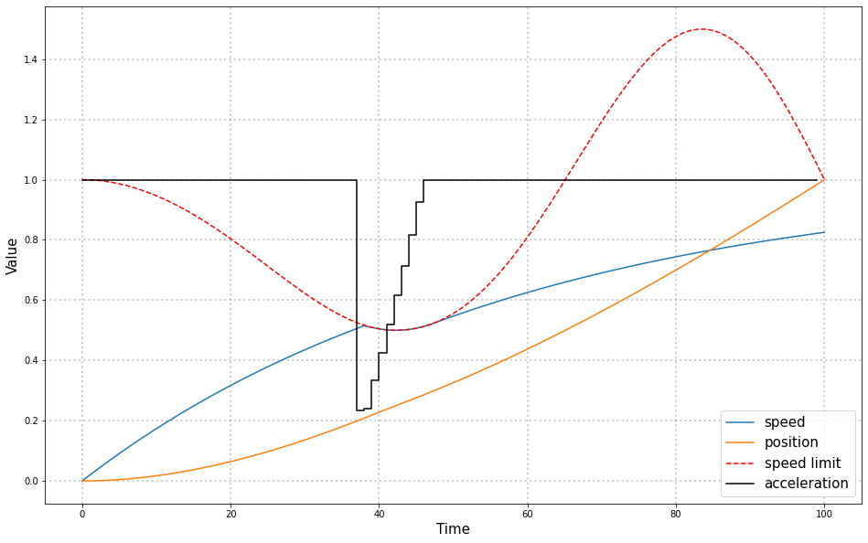

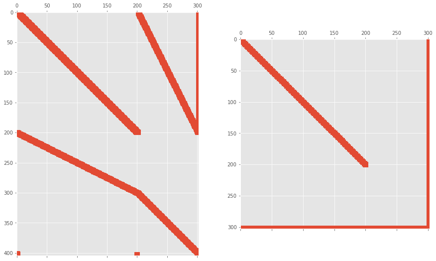

# Vehicle Steering Dynamics

The vehicle dynamics are given by a simple bicycle model. We take the state of the system as $(x, y, \theta)$ where $(x, y)$ is the position of the reference point of the vehicle in the plane and $\theta$ is the angle of the vehicle with respect to horizontal. The vehicle input is given by $(v, \delta)$ where $v$ is the forward velocity of the vehicle and $\delta$ is the angle of the steering wheel. We take as parameters the wheelbase $b$ and the offset $a$ between the rear wheels and the reference point. The model includes saturation of the vehicle steering angle (maxsteer).

- System state: x, y, theta
- System input: v, delta
- System output: x, y
- System parameters: wheelbase, refoffset, maxsteer

Assuming no slipping of the wheels, the motion of the vehicle is given by a rotation around a point O that depends on the steering angle $\delta$. To compute the angle $\alpha$ of the velocity of the reference point with respect to the axis of the vehicle, we let the distance from the center of rotation O to the contact point of the rear wheel be $r_\text{r}$ and it the follows from Figure 3.17 in FBS that $b = r_\text{r} \tan \delta$ and $a = r_\text{r} \tan \alpha$, which implies that $\tan \alpha = (a/b) \tan \delta$.

Reasonable limits for the steering angle depend on the speed. The physical limit is given in our model as 0.5 radians (about 30 degrees). However, this limit is rarely possible when the car is driving since it would cause the tires to slide on the pavement. We us a limit of 0.1 radians (about 6 degrees) at 10 m/s ($\approx$ 35 kph) and 0.05 radians (about 3 degrees) at 30 m/s ($\approx$ 110 kph). Note that a steering angle of 0.05 rad gives a cross acceleration of $(v^2/b) \tan \delta \approx (100/3) 0.05 = 1.7$ $\text{m/s}^2$ at 10 m/s and 15 $\text{m/s}^2$ at 30 m/s ($\approx$ 1.5 times the force of gravity).

## Vehicle driving on a curvy road

To illustrate the dynamics of the system, we create an input that correspond to driving down a curvy road. This trajectory will be used in future simulations as a reference trajectory for estimation and control.

```python
# System parameters
wheelbase = vehicle_params['wheelbase']
v0 = vehicle_params['velocity']

# Control inputs
T_curvy = np.linspace(0, 7, 500)
v_curvy = v0*np.ones(T_curvy.shape)
delta_curvy = 0.1*np.sin(T_curvy)*np.cos(4*T_curvy) + 0.0025*np.sin(T_curvy*np.pi/7)
u_curvy = [v_curvy, delta_curvy]
X0_curvy = [0, 0.8, 0]

# Simulate the system + estimator
t_curvy, y_curvy, x_curvy = ct.input_output_response(
    vehicle, T_curvy, u_curvy, X0_curvy, params=vehicle_params, return_x=True)
```

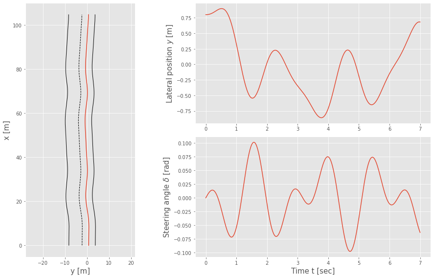

## Trajectory Generation

To illustrate how we can use a two degree-of-freedom design to improve the performance of the system, consider the problem of steering a car to change lanes on a road. We use the non-normalized form of the dynamics, which were derived in Example 3.11.

To find a trajectory from an initial state $x_0$ to a final state $x_\text{f}$ in time $T_\text{f}$ we solve a point-to-point trajectory generation problem. We also set the initial and final inputs, which sets the vehicle velocity $v$ and steering wheel angle $\delta$ at the endpoints.

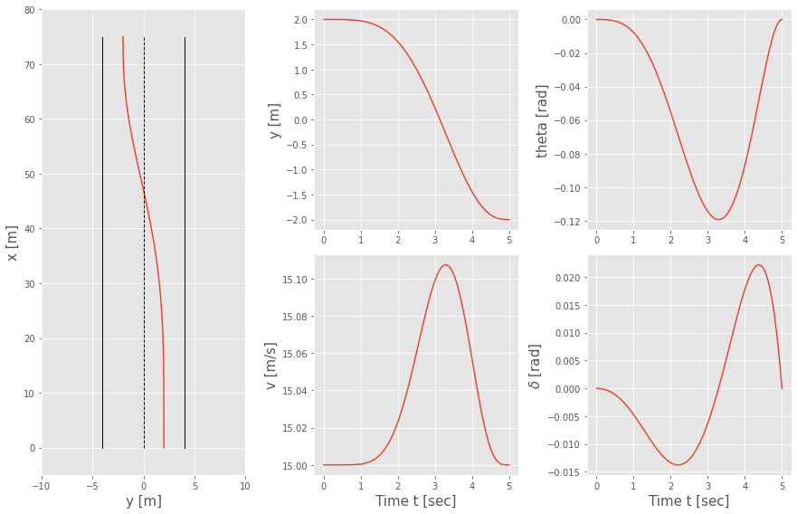

## Change of basis function using Beizer Curve

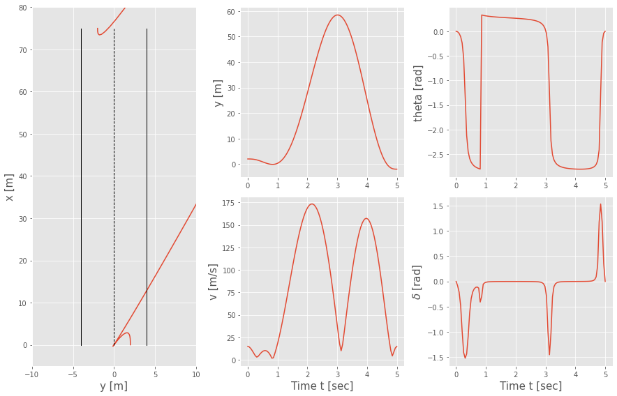

## Added cost function

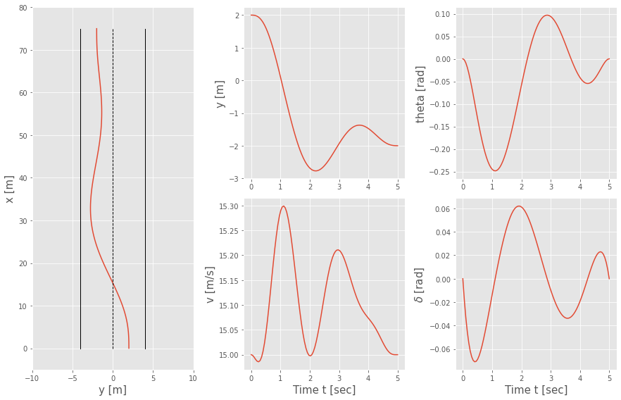

## Feedforward Compensation

For a lane transfer system we would like to have a nice response without overshoot, and we therefore consider the use of feedforward compensation to provide a reference trajectory for the closed loop system. We choose the desired response as $F_\text{m}(s) = a^22/(s + a)^2$, where the response speed or aggressiveness of the steering is governed by the parameter $a$.

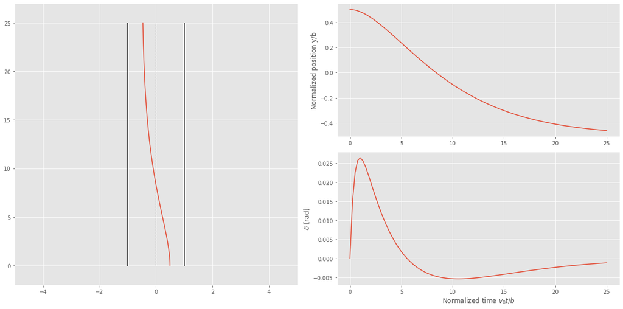

# Lane Change Maneuver

```python
x0 = [0., -2., 0.]; u0 = [5., 0.]
xf = [100., 2., 0.]; uf = [10., 0.]
Tf = 10
```

```python
Q = np.diag([0.1, 10, .1])    # keep lateral error low
R = np.eye(2) * 0.1
cost = opt.quadratic_cost(vehicle, Q, R, x0=xf, u0=uf)
```

```python
constraints = [ opt.input_range_constraint(vehicle, [8, -0.1], [12, 0.1]) ]
```

[figure not shown]